# Modeling Choices #01. Gaussian

Joon-Ho Lee (joonho@berkeley.edu)

February 23, 2020

# 1 Introduction

## 1.1 Bayes deconvolution problem

The basic two-stage sampling model that we focus on in this document is

$$y_{k}|\theta_{k} \sim N(\theta_{k}, \sigma_{k}^2),$$
$$\theta_{k}|G \overset{\text{iid}}{\sim} G,$$
$$G \sim f(G),$$

where $k = 1, ..., K$, $K$ is the number of second-stage units under analysis, $\sigma_{k}^2$ is the variance of the observed data, $y_{k}$, and $f(G)$ is the prior distribution of $G$. The site-specific parameters of interest, $\theta_{k} (k = 1, ..., K)$ comes from the population distribution, $G$. The observations, $y_{k} (k = 1, ..., K)$ comes from a Gaussian sampling distribution that depends on the $\theta_{k}$’s. The *Bayes deconvolution problem* is a general name for estimating $G$ given a random sample from the marginal density of $Y$ (Efron 2016).

## 1.2 The Rubin (1981) model[^1]

Now let us translate the sampling model into the Rubin (1981) model on parallel randomized experiments. Consider $K$ study sites in which researchers perform the same interventions and measure the same outcomes. Each site, indexed by $k$, estimates a treatment effect $\tau_k$ averaged across individuals in the site. The sites don’t report $\{\tau_k\}^{K}_{k=1}$: instead, they report $\{\hat{\tau}_k\}^{K}_{k=1}$. Some of the observed variation in $\{\hat{\tau}_k\}^{K}_{k=1}$ is sampling variation, yet there is likely to be some genuine variation in effects across settings, often defined as $\sigma_{\tau}^{2} = \text{var}(\tau_{k})$.

Rubin (1981) considers a case in which the analyst has access to a set of estimated effects $\{\hat{\tau}_k\}^{K}_{k=1}$ and estimates of the associated sampling errors $\{\hat{se}_{\tau_k}\}^{K}_{k=1}$. Rubin specifies a relationship between the observed estimates and the unobserved $\{\tau_k\}^{K}_{k=1}$, and in addition spcifies a relationship between $\{\tau_k\}^{K}_{k=1}$ and the aggregate parameters $(\tau, \sigma_{\tau}^2)$). The Rubin (1981) model has a hierarchical likelihood in which each site has own treatment effect parameter, $\tau_k$, but these effects are all drawn from a common distribution governed by $(\tau, \sigma_{\tau}^2)$ as follows:

$$\hat{\tau}_{k} \sim N(\tau_{k}, \hat{se}_{k}^2) \quad \forall k,$$
$$\tau_{k} \sim N(\tau, \sigma_{\tau}^2) \quad \forall k.$$

The Rubin (1981) model is fully parametric and a particular case of a more general class of models on $G$. The Gaussian distributional link between $\{\tau_k\}^{K}_{k=1}$ and $(\tau, \sigma_{\tau}^2)$ ensures that the model nests the analytic framework of classical meta-analysis, the results of which are recovered by setting $\sigma_{\tau}^{2} = 0$ (Gelman et al. 2013). If $\sigma_{\tau}^{2} = \infty$, the Rubin (1981) model returns the original estimates.

The Gaussian structure is tractable and offers lower mean squared error in many cases. McCulloch and Neuhaus (2011) has shown that Gaussian hierachical models generally deliver reliable inference on the mean $\tau$ and variance $\sigma_{\tau}^2$ even when the underlying true distribution is not Gaussian.

# 2 Generate simulated data from a Gaussian distribution

$G$ will be simulated to follow a Gaussian distribution with mean 0 and variance 1. We first set our simulation parameters to reflect a range of data informativeness and heterogeneity among sites with respect to variance.

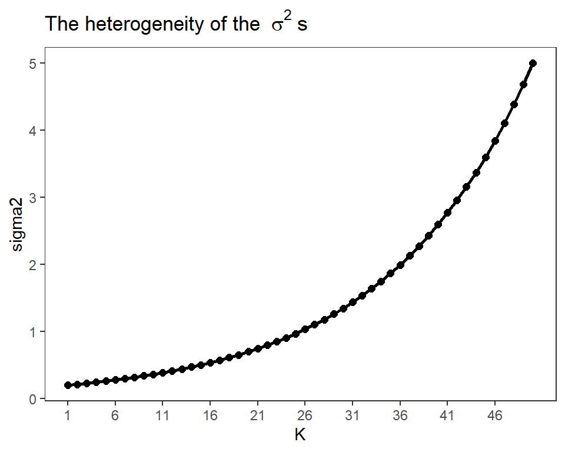

```r
### Example settings
n <- 50; rgt <- 1; rsr <- 5

### Set maximum and minimum within-site variances
sigma2max <- rgt*rsr
sigma2min <- sigma2max/(rsr^2)

### Generate within-site variances (sds) for K sites
sigma2 <- exp(seq(from = log(sigma2min), to = log(sigma2max), length = n))
sd <- sqrt(sigma2)

### Plot within-site variances
df_temp <- tibble(sigma2, sd) %>%
  mutate(K = 1:n())

ggplot(data = df_temp, aes(x = K, y = sigma2)) +
  geom_point(size = 2.0) + geom_path(size = 1.0) +
  scale_x_continuous(breaks = seq(1, n, by = 5)) +
  labs(title = bquote("The heterogeneity of the " ~ sigma^2 ~"s")) +
  theme_preset
```

The **R** function that follows simulates a dataset conforming to the Gaussian model.

```r
### Define a function to generate Gaussian random draws
GenerateGaussian <- function(n, rgt, rsr) {

  ### Generate within-site variances (sds) for K sites
  sigma2max <- rgt*rsr
  sigma2min <- sigma2max/(rsr^2)
  sigma2 <- exp(seq(from = log(sigma2min), to = log(sigma2max), length = n))
  sd <- sqrt(sigma2)

  ### Set mean and SD of standard normal distribution
  mn_tau <- 0; sigma_tau <- sqrt(1)

  ### Generate data (Note the difference between theta and Y)
  data_obj <- list()
  data_obj$tau_k <- rnorm(n, mn_tau, sigma_tau)        # site means
  data_obj$tau_k_hat <- rnorm(n, data_obj$tau_k, sd) # within-site outcome (only one per site)
  data_obj$se_k2 <- sigma2                  # site SDs
  return(data_obj)
}

### Generate sample draws from the Gaussian model
df_G <- GenerateGaussian(n = 50, rgt = 1, rsr = 5) %>%
  data.frame() %>%
  rownames_to_column("K") %>%
  mutate_at(.vars = c("K"), .funs = as.numeric)

head(df_G)
```

```
##   K      tau_k    tau_k_hat     se_k2
## 1 1  0.6191817  0.523959444 0.2000000
## 2 2  0.4572603 -0.004420145 0.2135794
## 3 3 -0.7467568 -0.936636449 0.2280808
## 4 4  1.1240690  1.568602041 0.2435668
## 5 5  0.7524245  0.305662483 0.2601043
## 6 6  0.8264540  0.204435202 0.2777646
```

Next, we compare the observed estimates ($\hat{\tau}_k$) to the true distribution of $\tau_k$.

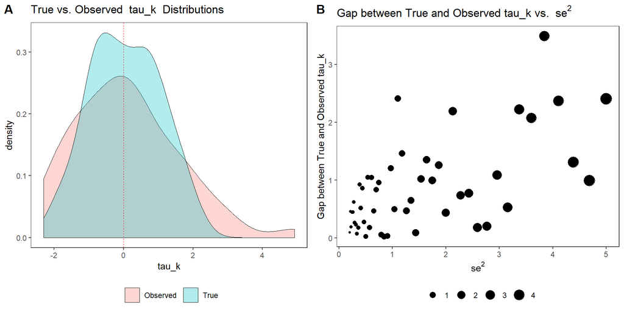

```r
### Define a function to generate plot
plot_compare_true_obs <- function(df_G){

  # Compare the true distribution (tau_k) to the observed data (tau_k_hat)
  df_plot <- df_G %>%
    select(tau_k, tau_k_hat) %>%
    rename(True = tau_k, Observed = tau_k_hat) %>%
    gather(key = variable, value = value)

  p1 <- ggplot(data = df_plot, aes(x = value, group = variable, fill = variable)) +
      geom_density(position = "identity", size = 0.1, alpha = 0.3) +
      geom_vline(aes(xintercept = 0), size = 0.3, color = "red", linetype = "dashed") +
      labs(title = bquote("True vs. Observed " ~ tau_k ~" Distributions"),
           x = expression(tau_k)) + theme_preset

  # Compare point estimates by sigma_k
  p2 <- ggplot(data = df_G %>% mutate(gap = abs(tau_k_hat - tau_k)),
               aes(x = se_k2, y = gap)) +
      geom_point(aes(size = se_k2)) +
    labs(title = bquote("Gap between True and Observed tau_k vs. " ~ se^2),
         y = bquote("Gap between True and Observed tau_k"),
         x = expression(se^2)) + theme_preset

  # Combine the two plots
  p_grid <- plot_grid(p1, p2, labels = "AUTO")
  return(p_grid)
}

plot_compare_true_obs(df_G)
```

The empirical distribution function (EDF) of the observed $\hat{\tau}_k$ is overdispersed due to the uncertainty of the observed data, $\hat{se}_k^2$. The discrepancy between true and observed $\tau_k$s tends to be larger for the sites with larger $\hat{se}_k^2$.

# 3 Parameter estimation using **Stan**

First, we obtain simulates from the posterior of a Gaussian model using **Stan**. The **Stan** program for the Rubin (1981) model is provided below:

```
data {
  int<lower = 0> K;         // number of sites
  real tau_hat_k[K];        // estimated treatment effects
  real<lower=0> se_k[K];    // s.e. of effect estimates
}
parameters {
  real tau;
  real<lower=0> sigma_tau;
  real tau_k[K];
}
model {
  sigma_tau ~ uniform(0, 100);     // vague prior
  tau ~ normal(0, 100);            // vague prior
  tau_k ~ normal(tau, sigma_tau);   // second-level normal
  tau_hat_k ~ normal(tau_k, se_k);  // third-level normal
}
generated quantities{
  real predicted_tau_k;
  predicted_tau_k = normal_rng(tau, sigma_tau);  //mixed predictive
}
```

Note that the Rubin model assumes Gaussian distribution of effects across sites. The Rubin model performs univariate shrinkage so we will not need to specify a hyper-correlation prior. But we need to specify hyperpriors on the hyper-mean $\tau$ and hyper-SD $\sigma_{\tau}$:

The model specified in the Stan program is fit to the simulated data:

```r
### Collect data into a list format suitable for Stan
stan_data <- list(K = length(df_G$K),
                  tau_hat_k = df_G$tau_k_hat,
                  se_k = sqrt(df_G$se_k2))

### Compile and run the stan model
fit_rubin<- stan(file = "rubin_model_01_Gaussian.stan",
                 data = stan_data,
                 iter = 1000, chains = 4)
```

The posterior means and standard deviations of the parameters can be displayed as follows:

```r
print(fit_rubin, probs = c(0.1, 0.5, 0.9), digits = 3)
```

```
## Inference for Stan model: rubin_model_01_Gaussian.
## 4 chains, each with iter=1000; warmup=500; thin=1;
## post-warmup draws per chain=500, total post-warmup draws=2000.
##
##                    mean se_mean    sd     10%     50%     90% n_eff  Rhat
## tau              -0.080   0.004 0.198  -0.323  -0.090   0.171  2156 1.001
## sigma_tau         0.978   0.007 0.189   0.752   0.962   1.231   671 1.005
## tau_k[1]          0.402   0.007 0.418  -0.119   0.393   0.951  3491 0.999
## tau_k[2]         -0.011   0.007 0.444  -0.580  -0.011   0.560  3745 0.999
## tau_k[3]         -0.762   0.007 0.427  -1.318  -0.748  -0.219  3724 0.998
## tau_k[4]          1.210   0.010 0.471   0.633   1.206   1.819  2375 0.999
## tau_k[5]          0.212   0.008 0.438  -0.327   0.203   0.778  3098 1.000
## tau_k[6]          0.134   0.007 0.465  -0.480   0.141   0.735  4708 0.998
## tau_k[7]          0.349   0.008 0.480  -0.253   0.352   0.960  3473 0.999
## tau_k[8]          1.039   0.010 0.511   0.400   1.032   1.695  2433 1.000
## tau_k[9]         -1.257   0.010 0.498  -1.901  -1.240  -0.613  2732 0.999
## tau_k[10]        -0.060   0.008 0.503  -0.724  -0.053   0.574  3624 1.000
## tau_k[11]        -0.603   0.008 0.512  -1.258  -0.600   0.036  3923 0.999
## tau_k[12]        -1.009   0.010 0.530  -1.705  -0.993  -0.343  2898 1.000
## tau_k[13]        -1.130   0.010 0.557  -1.830  -1.133  -0.434  3068 0.999
## tau_k[14]        -0.387   0.010 0.563  -1.110  -0.388   0.337  3311 0.999
## tau_k[15]        -1.277   0.012 0.621  -2.085  -1.273  -0.486  2822 0.999
## tau_k[16]         1.501   0.013 0.619   0.709   1.475   2.273  2153 1.000
## tau_k[17]        -0.594   0.011 0.598  -1.366  -0.597   0.157  3049 0.999
## tau_k[18]        -1.027   0.012 0.644  -1.860  -1.010  -0.207  2768 1.002
## tau_k[19]        -1.148   0.012 0.652  -2.004  -1.129  -0.348  3116 0.999
## tau_k[20]        -0.583   0.010 0.642  -1.415  -0.580   0.243  3972 0.999
## tau_k[21]         0.559   0.011 0.636  -0.258   0.564   1.371  3115 0.998
## tau_k[22]        -0.123   0.010 0.641  -0.937  -0.123   0.697  3815 1.000
## tau_k[23]        -0.117   0.011 0.676  -0.962  -0.127   0.775  3508 1.000
## tau_k[24]         0.330   0.011 0.686  -0.526   0.318   1.220  3677 0.999
## tau_k[25]        -1.185   0.014 0.734  -2.125  -1.190  -0.274  2567 1.000
## tau_k[26]         0.213   0.012 0.697  -0.699   0.218   1.070  3152 1.002
## tau_k[27]         0.650   0.014 0.740  -0.262   0.650   1.607  2900 1.000
## tau_k[28]        -0.613   0.012 0.734  -1.578  -0.597   0.311  3541 0.998
## tau_k[29]        -0.563   0.013 0.724  -1.457  -0.556   0.326  3297 0.999
## tau_k[30]         0.205   0.013 0.746  -0.752   0.187   1.165  3197 1.000
## tau_k[31]        -0.352   0.013 0.750  -1.340  -0.333   0.575  3250 1.000
## tau_k[32]        -0.205   0.013 0.762  -1.178  -0.205   0.761  3679 0.998
## tau_k[33]         0.053   0.012 0.773  -0.903   0.049   1.013  3868 0.999
```

[output cut: 9 more lines]

```
## tau_k[43]        -0.026   0.015 0.844  -1.107  -0.038   1.064  3035 0.999
## tau_k[44]        -0.143   0.015 0.881  -1.256  -0.139   0.945  3401 1.000
## tau_k[45]         0.352   0.015 0.906  -0.782   0.309   1.517  3543 1.000
## tau_k[46]         0.907   0.018 0.943  -0.227   0.855   2.123  2705 1.000
## tau_k[47]         0.045   0.015 0.903  -1.074   0.047   1.205  3577 0.999
## tau_k[48]         0.459   0.017 0.947  -0.730   0.427   1.674  3281 0.999
## tau_k[49]        -0.320   0.015 0.905  -1.476  -0.313   0.818  3865 0.999
## tau_k[50]         0.286   0.018 0.944  -0.897   0.294   1.493  2723 0.999
## predicted_tau_k  -0.074   0.022 1.042  -1.364  -0.087   1.253  2213 1.000
## lp__            -47.156   0.319 6.961 -55.837 -46.937 -38.625   477 1.010
##
## Samples were drawn using NUTS(diag_e) at Mon Feb 24 16:47:32 2020.
## For each parameter, n_eff is a crude measure of effective sample size,
## and Rhat is the potential scale reduction factor on split chains (at
## convergence, Rhat=1).
```

Before interpreting the results, it is necessary to check that the chains have converged for each parameter. The $\hat{R}$ statistics shown in the rightmost column of the model summary are all less than 1.1. Also the effective sample size estimates are sufficient for inference. Thus it seems that **Stan** has produced an adequate approximation of the posterior.

Then, we extract posterior samples and save it for later comparison with estimates from `hhsim` package.

```r
### Extract posterior samples
posterior <- as.data.frame(fit_rubin) %>%
  mutate(Type = "Stan") %>%
  dplyr::select(Type, everything())
dim(posterior)
```

```
## [1] 2000   55
```

# 4 Parameter estimation using the `hhsim` package

Second, we obtain simulates from the posterior of a Gaussian model using the `hhsim` package. The **Stan** program above runs 4 chains with a burn-in period of 500 iterations followed by 500 additional iterations per chain. Since the `hhsim` package does not use separate chains, we set the number of MCMC and burn-in iterations to 2,000, respectively, in order for the total iterations to be the same with those of the **Stan** program.

```r
### Set numbers of iterations
nmcmc <- 2000    # number of MCMC iterations per each model fit
nburn <- 2000    # burn-in iterations to discard at each round
nmcmcall <- nmcmc + nburn

### Extract vectors of observed tau_ks and their SEs
Y <- df_G$tau_k_hat   # a vector of observed tau_ks
sigma2 <- df_G$se_k2  # a vector of known SEs
nDraws <- nmcmcall    # number of MCMC draws

### Estimate the Gaussian model using hhsim package
outp <- GaussianGaussian(Y, sigma2, nDraws)

### Define a function to tidy up the output object
get_posterior_sample <- function(output = outp, nburn = 100, nmcmcall = 600){

  # (1) Tidy up the "theta" output object
  df_theta <- outp[["theta"]] %>%
    unlist() %>%
    matrix(nrow = length(outp[["theta"]]), byrow = TRUE) %>%
    data.frame() %>%
    slice(c((nburn + 1):nmcmcall))  # throw away burn-ins
  colnames(df_theta) <- paste0("tau_k[", seq(ncol(df_theta)), "]")

  # (2) Tidy up the "tau" and "sigma_tau" output objects
  df_hyperparm <- outp[["m"]] %>%
    cbind.data.frame(outp[["tau2"]]) %>%
    slice(c((nburn + 1):nmcmcall))  # throw away burn-ins
  colnames(df_hyperparm) <- c("tau", "sigma_tau")

  ### Return the resulting object
  cbind.data.frame(df_hyperparm, df_theta)
}

### Save posterior samples
posterior_hhsim <- get_posterior_sample(outp, nburn, nmcmcall) %>%
  mutate(Type = "hhsim") %>% dplyr::select(Type, everything())
```

# 5 Comparison of posterior samples obtained from **Stan** and `hhsim`

Would the **Stan** program and `hhsim` package lead to the same estimates? We start from combining the two data frames containing posterior samples:

```r
### Combine two dataframes: Stan and hhsim
df_combine <- posterior %>%
  dplyr::select(-predicted_tau_k, -lp__) %>%
  bind_rows(posterior_hhsim) %>%
  mutate(Type = factor(Type, levels = c("Stan", "hhsim")))
```

## 5.1 Hyperparameters $\tau$ and $\sigma_{\tau}$

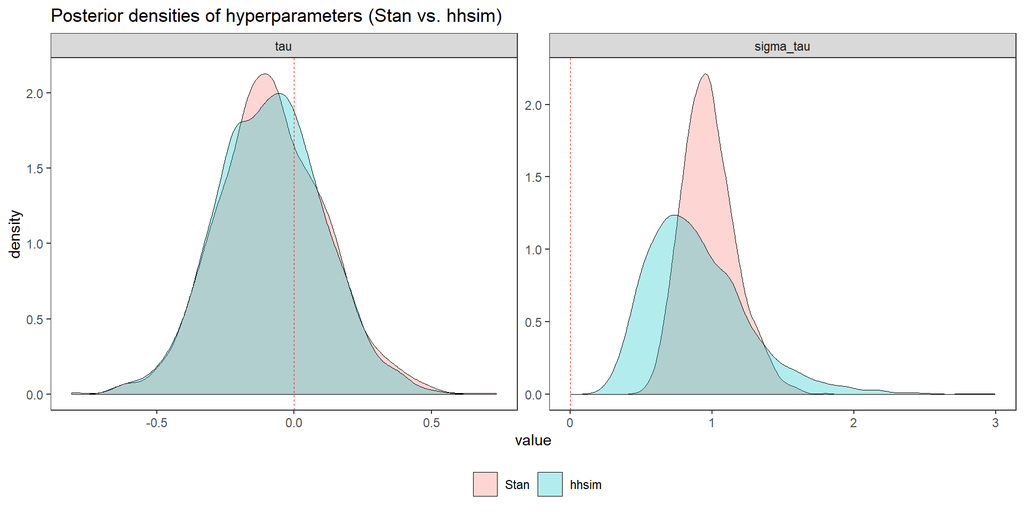

```r
### Generate a dataframe to plot
df_plot <- df_combine %>%
  dplyr::select(Type, tau, sigma_tau) %>%
  gather(key = variable, value = value, -Type) %>%
  mutate(variable = factor(variable, levels = c("tau", "sigma_tau")))

### Define a function to generate plot
plot_compare_density <- function(df_plot, title = title){
  ggplot(data = df_plot, aes(x = value, group = Type, fill = Type)) +
    geom_density(position = "identity", size = 0.1, alpha = 0.3) +
    geom_vline(aes(xintercept = 0), size = 0.3, color = "red", linetype = "dashed") +
    labs(title = title) + theme_preset
}

plot_compare_density(df_plot, title = "Posterior densities of hyperparameters (Stan vs. hhsim)") +
  facet_wrap(~ variable, scales = "free")
```

## 5.2 Empirical distribution function (EDF) estimates for $\tau_{k}$s

```r
df_temp <- df_combine %>%
  dplyr::select(Type, contains("tau_k[")) %>%
  gather(key = variable, value = value, -Type) %>%
  group_by(Type, variable) %>%
  summarise(mean = mean(value, na.rm = TRUE),
            sd = sd(value, na.rm = TRUE)) %>%
  mutate(id = as.numeric(str_extract(variable, "\\d+"))) %>%
  arrange(id, Type)

head(df_temp, 10)
```

```
## # A tibble: 10 x 5
## # Groups:   Type [2]
##    Type  variable    mean    sd    id
##    <fct> <chr>      <dbl> <dbl> <dbl>
##  1 Stan  tau_k[1]  0.402  0.418     1
##  2 hhsim tau_k[1]  0.391  0.417     1
##  3 Stan  tau_k[2] -0.0114 0.444     2
##  4 hhsim tau_k[2] -0.0157 0.409     2
##  5 Stan  tau_k[3] -0.762  0.427     3
##  6 hhsim tau_k[3] -0.750  0.421     3
##  7 Stan  tau_k[4]  1.21   0.471     4
##  8 hhsim tau_k[4]  1.20   0.442     4
##  9 Stan  tau_k[5]  0.212  0.438     5
## 10 hhsim tau_k[5]  0.202  0.450     5
```

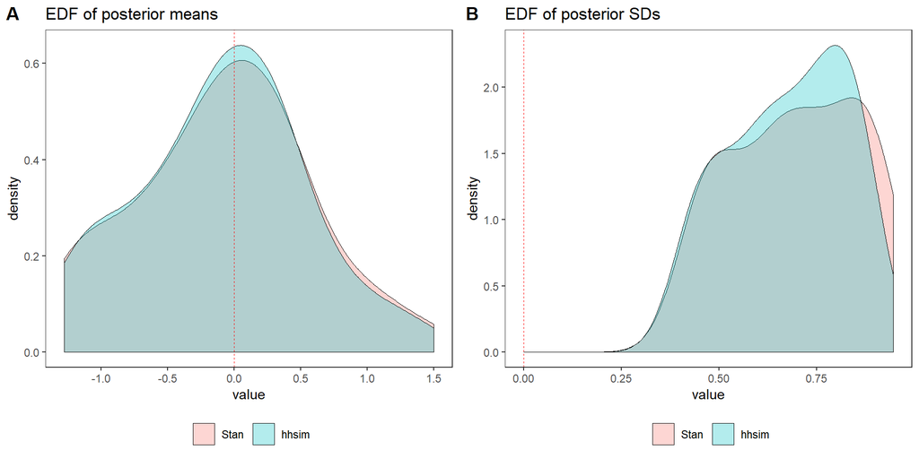

```r
p1 <- plot_compare_density(df_temp %>% rename(value = mean), title = "EDF of posterior means")
p2 <- plot_compare_density(df_temp %>% rename(value = sd), title = "EDF of posterior SDs")
plot_grid(p1, p2, labels = "AUTO")
```

## 5.3 Site-specific individual effect estimates $\tau_{k}$s

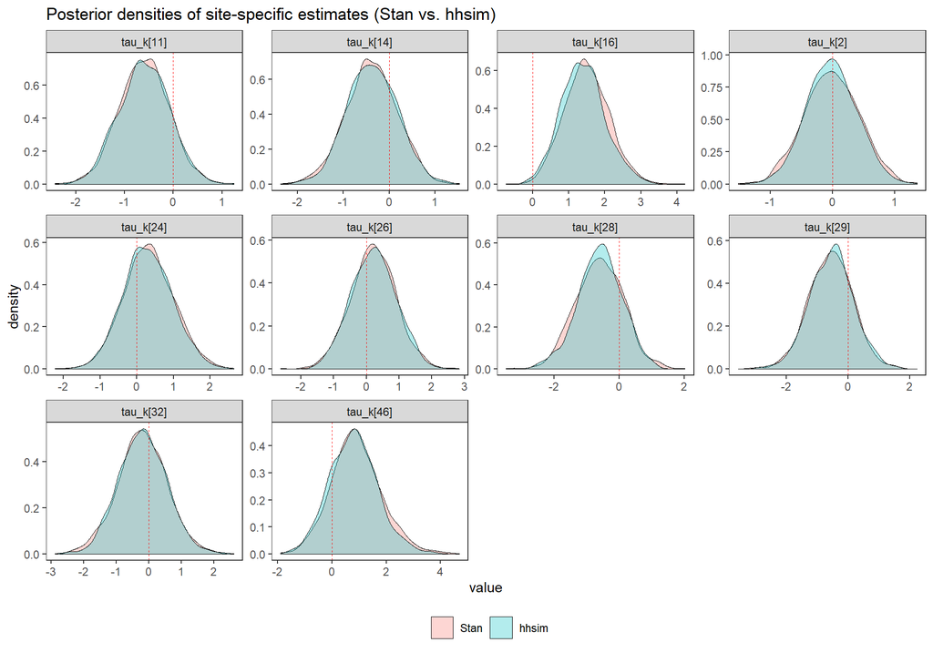

```r
### Compare densities: site-specific estiamtes
set.seed(12345)
rand_var <- paste0("tau_k[", sample(1:50, 10, replace = FALSE), "]")

df_plot <- df_combine %>%
  dplyr::select(Type, rand_var) %>%
  gather(key = variable, value = value, -Type)

title <- "Posterior densities of site-specific estimates (Stan vs. hhsim)"
plot_compare_density(df_plot, title = title) +
  facet_wrap(~ variable, scales = "free")
```

# References

Efron, Bradley. 2016. “Empirical Bayes Deconvolution Estimates.” *Biometrika* 103 (1): 1–20.

Gelman, Andrew, John B Carlin, Hal S Stern, David B Dunson, Aki Vehtari, and Donald B Rubin. 2013. *Bayesian Data Analysis*. Chapman; Hall/CRC.

McCulloch, Charles E, and John M Neuhaus. 2011. “Misspecifying the Shape of a Random Effects Distribution: Why Getting It Wrong May Not Matter.” *Statistical Science*, 388–402.

Meager, Rachael. 2019. “Understanding the Average Impact of Microcredit Expansions: A Bayesian Hierarchical Analysis of Seven Randomized Experiments.” *American Economic Journal: Applied Economics* 11 (1): 57–91.

Rubin, Donald B. 1981. “Estimation in Parallel Randomized Experiments.” *Journal of Educational Statistics* 6 (4): 377–401.

[^1]: See Meager (2019) pp. 62-63.